# A3 - Modelització predictiva

Xavier Maltas Tarridas

Desembre 2022

# 1 Regressió lineal

## 1.1 Model de regressió lineal (variables quantitatives)

En aquest apartat intentarem respondre diverses preguntes relacionades amb el retard d’un vol i la distància entre destins mitjançant l’ús de models de regressió lineal. El mètode seleccionat és el **mètode dels mínims quadrats** on busquem que la suma dels quadrats dels residus sigui mínima. Considerem com a residu, la diferència de distància vertical entre punt del valor observat i recta de regressió.

### 1.1.1 Arrival delay - Distance

En primer lloc, se’ns demana observar la relació entre les variables *Arrival_Delay* i *Distance*. Realitzarem una representació gràfica de com es dispersen els valors tenint en compte aquests dos paràmetres.

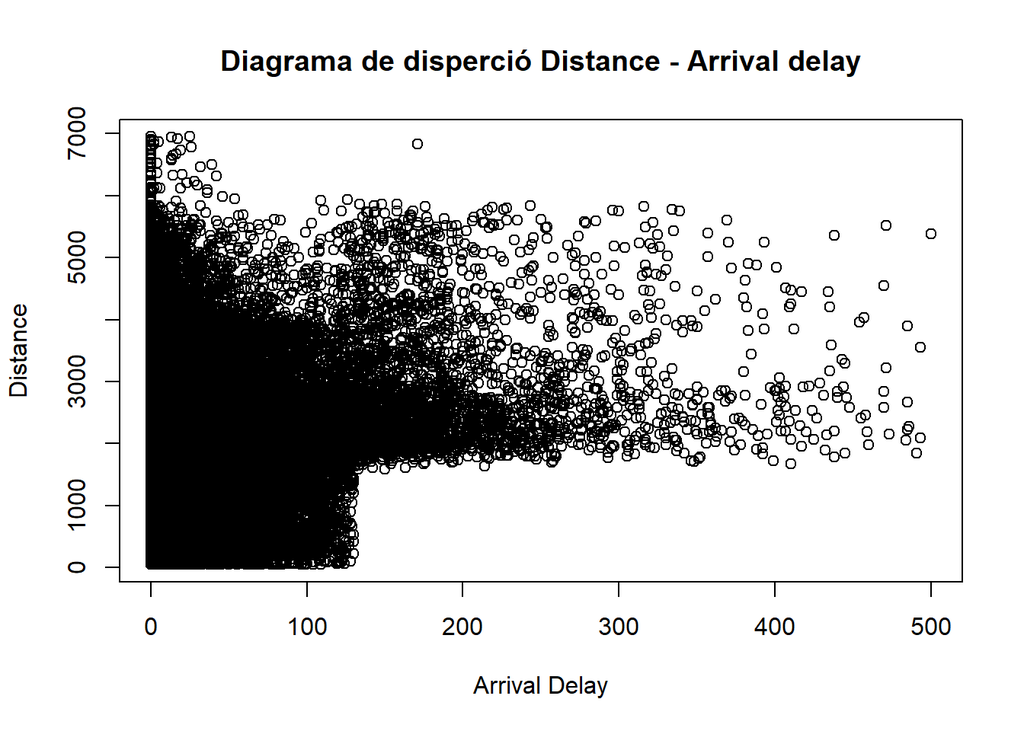

```r
#scatter plot
plot.scatter.distanceArrivaldelay <- plot(Distance~Arrival_Delay, data = df, main="Diagrama de disperció Distance - Arrival delay", xlab="Arrival Delay", ylab="Distance")
```

A continuació, generem un model de regressió lineal tenint els dos paràmetres.

```r
#src: https://www.cyclismo.org/tutorial/R/linearLeastSquares.html
#Arrival_Delay - Distance Model
model.linearRegression.arrivaldelayDistance<- lm(Arrival_Delay~Distance, data=df)
summary(model.linearRegression.arrivaldelayDistance)
```

```
##
## Call:
## lm(formula = Arrival_Delay ~ Distance, data = df)
##
## Residuals:
##    Min     1Q Median     3Q    Max
## -34.00 -15.30 -11.74  -1.29 477.72
##
## Coefficients:
##              Estimate Std. Error t value Pr(>|t|)
## (Intercept) 7.239e+00  2.166e-01   33.42   <2e-16 ***
## Distance    3.850e-03  9.709e-05   39.66   <2e-16 ***
## ---
## Signif. codes:  0 '***' 0.001 '**' 0.01 '*' 0.05 '.' 0.1 ' ' 1
##
## Residual standard error: 35.86 on 129444 degrees of freedom
## Multiple R-squared:  0.012,  Adjusted R-squared:  0.012
## F-statistic:  1573 on 1 and 129444 DF,  p-value: < 2.2e-16
```

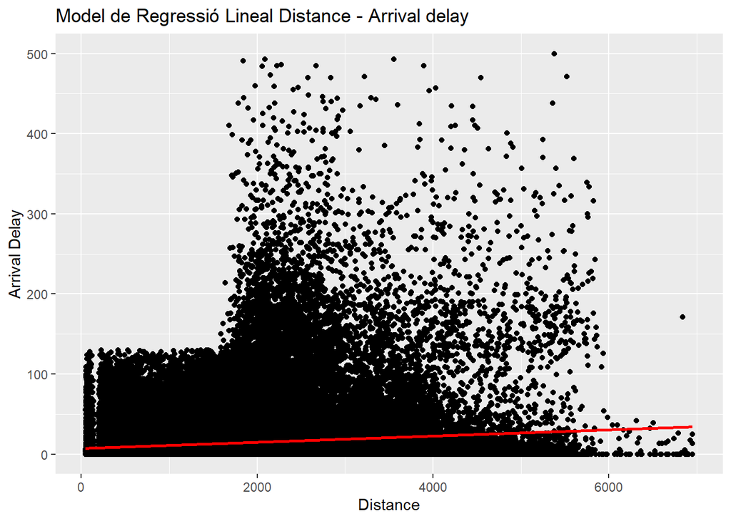

```r
#Linear Regression model plot over scatter plot Distance-Arrival delay
plot.scatter.lm.distanceArrivaldelay <- ggplot(df, aes(x = Distance, y = Arrival_Delay)) +
  ggtitle("Model de Regressió Lineal Distance - Arrival delay") + xlab("Distance") + ylab("Arrival Delay") +
  geom_point() +
  stat_smooth(method = "lm", col = "red")
plot.scatter.lm.distanceArrivaldelay
```

### 1.1.2 Arrival delay - Distance - Departure delay

En aquest segon apartat afegirem al model anterior la variable *Departure_Delay*.

```r
#Arrival_Delay - Distance - Departure_Delay Model
model.linearRegression.arrivaldelayDistanceDeparturedelay<- lm(Arrival_Delay~Distance+Departure_Delay, data=df)
summary(model.linearRegression.arrivaldelayDistanceDeparturedelay)
```

```
##
## Call:
## lm(formula = Arrival_Delay ~ Distance + Departure_Delay, data = df)
##
## Residuals:
##     Min      1Q  Median      3Q     Max
## -53.422  -1.951  -0.787  -0.404 236.671
##
## Coefficients:
##                  Estimate Std. Error  t value Pr(>|t|)
## (Intercept)     6.030e-01  6.083e-02    9.913  < 2e-16 ***
## Distance        9.530e-05  2.733e-05    3.487 0.000488 ***
## Departure_Delay 9.761e-01  7.905e-04 1234.821  < 2e-16 ***
## ---
## Signif. codes:  0 '***' 0.001 '**' 0.01 '*' 0.05 '.' 0.1 ' ' 1
##
## Residual standard error: 10.03 on 129443 degrees of freedom
## Multiple R-squared:  0.9227, Adjusted R-squared:  0.9227
## F-statistic: 7.724e+05 on 2 and 129443 DF,  p-value: < 2.2e-16
```

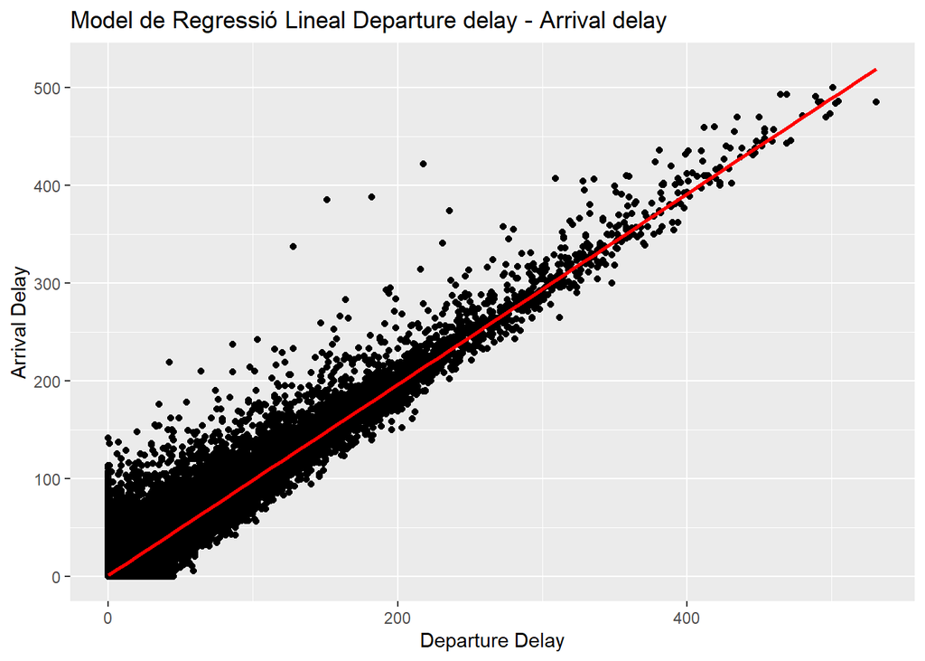

```r
#Linear Regression model plot over scatter plot Departure delay - Arrival delay
plot.scatter.lm.departuredelayArrivaldelay <- ggplot(df, aes(x = Departure_Delay, y = Arrival_Delay)) +
  ggtitle("Model de Regressió Lineal Departure delay - Arrival delay") + xlab("Departure Delay") + ylab("Arrival Delay") +
  geom_point() +
  stat_smooth(method = "lm", col = "red")
plot.scatter.lm.departuredelayArrivaldelay
```

## 1.2 Model de regressió lineal (variables quantitatives i qualitatives)

En aquest segon punt, treballarem utilitzant variables de tipus quantitatives com l’apartat anterior, però hi afegirem variables qualitatives per tal d’observar si aquestes poden afectar en el grau de satisfacció en general dels clients. Les noves variables afegides són: *Service*, *Food_drink*, *satisfaction* i *Customer_Type*.

### 1.2.1 ModelF

A l’enunciat se’ns plantejen diferents hipòtesis que podem estudiar previament per tal de determinar si certes variables tenen una relació líneal respecte altres.

En primer lloc, volem observar si el menjar, beguda i servei entregat pot fer variar o no el retard d’un vol. Segons el que ens mostra el resultat obtingut, els dos paràmetres tenen un alt nivell de significança, element que té sentit, ja que les companyies dediquen una quantitat de temps extra previ al vol que pot fer que influeixi en el retard d’arribada. Tot i això, quan ens fixem en el coeficient de determinació ajustat, veiem que aquest pren un valor molt petit (0.001965). És per aquest motiu, que ens pot portar pensar que aquestes dues variables no tenen gairebé incidència a la variable *Arrival_Delay*.

```r
#model
model.a <- lm(Arrival_Delay~Service+Food_drink, data=df)
summary(model.a)
```

```
##
## Call:
## lm(formula = Arrival_Delay ~ Service + Food_drink, data = df)
##
## Residuals:
##    Min     1Q Median     3Q    Max
## -18.98 -14.80 -13.29  -1.80 482.80
##
## Coefficients:
##             Estimate Std. Error t value Pr(>|t|)
## (Intercept) 19.90620    0.34618  57.502  < 2e-16 ***
## Service     -1.19996    0.07890 -15.209  < 2e-16 ***
## Food_drink  -0.30970    0.06945  -4.459 8.23e-06 ***
## ---
## Signif. codes:  0 '***' 0.001 '**' 0.01 '*' 0.05 '.' 0.1 ' ' 1
##
## Residual standard error: 36.05 on 129443 degrees of freedom
## Multiple R-squared:  0.00198,    Adjusted R-squared:  0.001965
## F-statistic: 128.4 on 2 and 129443 DF,  p-value: < 2.2e-16
```

En segon lloc, desitgem veure si com major és el retard, pot afectar a la satisfacció en general de l’experiència al client. Abans de calcular aquesta relació, hem de fer un pas previa, creant una nova variable numerica anomenada *numericSatisfaction*, on es fa una relació entre els valors de la satisfacció del client *‘nuetral or dissatisfied’* a 0 i *‘satisfied’* a 1. Amb els resultats obtinguts, podem veure que tot i tenir un alt nivell de significança donat el p-valor obtingut, quan ens fixem al coeficient de determinació ajustat (0.006859), podem afirmar que la incidència a la variable dependent és pràcticament nul·la.

```r
#value remap and cast to integer
satisfactionTointeger <- function(input) {
  input [input == "neutral or dissatisfied"] <- 0
  input [input == "satisfied"] <- 1
  input <- as.integer(input)
}
df$numericSatisfaction <- satisfactionTointeger(df$satisfaction)

#cast characters to factor
castToFactor <- function(input){
  input <- as.factor(input)
}

df$satisfaction <- castToFactor(df$satisfaction)
df$Gender <- castToFactor(df$Gender)
df$Customer_Type <- castToFactor(df$Customer_Type)
df$Class <- castToFactor(df$Class)
df$Type_Travel <- castToFactor(df$Type_Travel)

#model
model.b <- lm(numericSatisfaction~Arrival_Delay, data=df)
summary(model.b)
```

```
##
## Call:
## lm(formula = numericSatisfaction ~ Arrival_Delay, data = df)
##
## Residuals:
##     Min      1Q  Median      3Q     Max
## -0.5645 -0.5611  0.4355  0.4355  1.0071
##
## Coefficients:
##                 Estimate Std. Error t value Pr(>|t|)
## (Intercept)    5.645e-01  1.491e-03  378.56   <2e-16 ***
## Arrival_Delay -1.143e-03  3.821e-05  -29.92   <2e-16 ***
## ---
## Signif. codes:  0 '***' 0.001 '**' 0.01 '*' 0.05 '.' 0.1 ' ' 1
##
## Residual standard error: 0.496 on 129444 degrees of freedom
## Multiple R-squared:  0.006867,   Adjusted R-squared:  0.006859
## F-statistic:   895 on 1 and 129444 DF,  p-value: < 2.2e-16
```

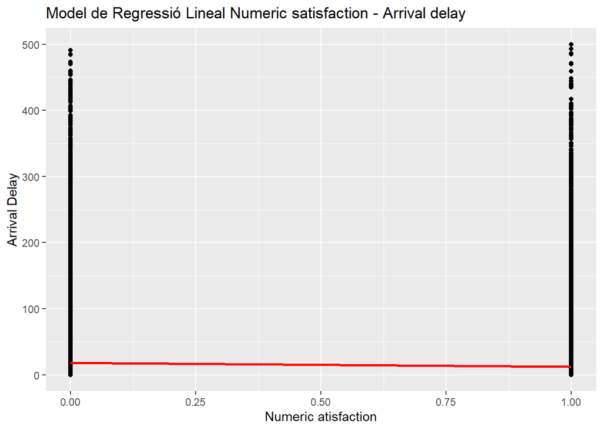

```r
#plot
ggplot(df, aes(x = numericSatisfaction, y = Arrival_Delay)) +
  ggtitle("Model de Regressió Lineal Numeric satisfaction - Arrival delay") + xlab("Numeric atisfaction") + ylab("Arrival Delay") +
  geom_point() +
  stat_smooth(method = "lm", col = "red")
```

Finalment, desitgem veure si ser un client lleial, pot o no influir en el retard del vol. En aquest cas estem treballant amb una variable categòrica, *Customer_Type*, on una categoria serveix de referència i les altres es tenen en compte al model. El resultat obtingut per als clients lleials té un pendent negatiu, això ens porta a pensar que clients que són lleials, tenen un menor retard d’arribada. En realitzar l’estimador de l’OR sobre la variable *Customer_Type*, veiem que l’ocurrència de percepció de retard d’arribada d’un vol en un client lleial és 0.5427011 vegades menor en relació amb el dels clients no lleials.

```r
#model
model.c <- lm(Arrival_Delay~Customer_Type,data=df)
summary(model.c)
```

```
##
## Call:
## lm(formula = Arrival_Delay ~ Customer_Type, data = df)
##
## Residuals:
##    Min     1Q Median     3Q    Max
## -15.36 -14.75 -14.75  -1.75 485.25
##
## Coefficients:
##                             Estimate Std. Error t value Pr(>|t|)
## (Intercept)                  15.3639     0.2343  65.570   <2e-16 ***
## Customer_TypeLoyal Customer  -0.6112     0.2593  -2.357   0.0184 *
## ---
## Signif. codes:  0 '***' 0.001 '**' 0.01 '*' 0.05 '.' 0.1 ' ' 1
##
## Residual standard error: 36.08 on 129444 degrees of freedom
## Multiple R-squared:  4.293e-05,  Adjusted R-squared:  3.521e-05
## F-statistic: 5.558 on 1 and 129444 DF,  p-value: 0.0184
```

```r
#OR
exp(coefficients(model.c))
```

```
##                 (Intercept) Customer_TypeLoyal Customer
##                4.704073e+06                5.427011e-01
```

```r
#model
model.linearRegression.F <- lm(formula=Arrival_Delay~Distance+Departure_Delay+Service+Food_drink+Customer_Type+numericSatisfaction, data=df)
summary(model.linearRegression.F)
```

```
##
## Call:
## lm(formula = Arrival_Delay ~ Distance + Departure_Delay + Service +
##     Food_drink + Customer_Type + numericSatisfaction, data = df)
##
## Residuals:
##     Min      1Q  Median      3Q     Max
## -53.770  -2.186  -0.668  -0.194 237.002
##
## Coefficients:
##                               Estimate Std. Error  t value Pr(>|t|)
## (Intercept)                  1.143e+00  1.239e-01    9.227  < 2e-16 ***
## Distance                     8.383e-05  2.733e-05    3.067  0.00216 **
## Departure_Delay              9.753e-01  7.922e-04 1231.181  < 2e-16 ***
## Service                     -6.457e-02  2.344e-02   -2.755  0.00588 **
## Food_drink                  -2.467e-02  1.945e-02   -1.268  0.20464
## Customer_TypeLoyal Customer  2.137e-01  7.537e-02    2.836  0.00457 **
## numericSatisfaction         -7.060e-01  6.285e-02  -11.233  < 2e-16 ***
## ---
## Signif. codes:  0 '***' 0.001 '**' 0.01 '*' 0.05 '.' 0.1 ' ' 1
##
## Residual standard error: 10.03 on 129439 degrees of freedom
## Multiple R-squared:  0.9228, Adjusted R-squared:  0.9228
## F-statistic: 2.579e+05 on 6 and 129439 DF,  p-value: < 2.2e-16
```

### 1.2.2 Col·linealitat ModelF

En un problema de regressió lineal múltiple esperem observar una dependència entre la variable dependent i un conjunt de variables explicatives, però en alguns casos ens podem trobar en el fet que alguna de les variables independents sigui una combinació lineal d’una de les altres variables independents. Creant així un problema de multicol·linealitat i afectant el còmput dels coeficients de la regressió.

Per a trobar possibles casos de correlació entre variables, hem anat buscant entre diferents combinacions de variables. En primer lloc, hem trobat una alta correlació entre les variables *Departure_Delay* i *Arrival_Delay*, amb un coeficient de correlació corresponent a 0.9605, indicant d’aquesta manera una presència de col·linealitat entre aquestes dues variables.

```r
#correlation DepartureDelay-ArrivalDelay
cor(x = df$Arrival_Delay, y = df$Departure_Delay, method = "pearson", use="pairwise.complete.obs")
```

```
## [1] 0.9605634
```

```r
#correlation numericSatisfaction-Service
cor(x = df$numericSatisfaction, y = df$Service, method = "pearson", use="pairwise.complete.obs")
```

```
## [1] 0.35234
```

A continuació, procedirem a detectar possibles efectes de multicol·linealitat, on un dels efectes principals és la inflació de la variància i covariància dels estimadors. Utilitzarem el factor d’inflació de la variància FIV.

```r
#src: https://fhernanb.github.io/libro_regresion/multicoli.html
#VIF
library(car)
vif(model.linearRegression.F)
```

```
##            Distance     Departure_Delay             Service          Food_drink
##            1.013961            1.018269            1.142791            1.014975
##       Customer_Type numericSatisfaction
##            1.094740            1.260335
```

El factor d’inflació de la variància calcula per a cada variable l’efecte combinat que tenen les dependències entre els diferents regressors sobre la variància de cada variable. Si ens trobem amb el cas on un o múltiples factors FIV prenen un valor gran, podem afirmar que tenim un cas de multicol·linealitat. Aplicat als nostres resultats, podem veure que els coeficients de totes les variables prenen valors relativament petits.

## 1.3 Diagnosi del model

Per realitzar la diagnosi del model construit, es demanen dos gràfics. A continuació, implementarem un gràfic amb els valors ajustats enfront dels residus, per observar si la variància és constant. A la vegada, implementarem un gràfic quantil-quantil per comparar els residus del model amb els valors d’una variable que es distribueix de forma normal.

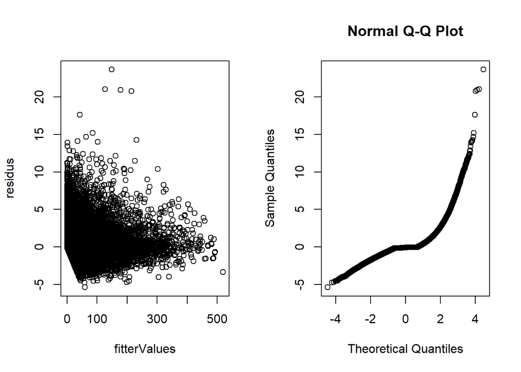

```r
#valors residus
residus <- rstandard(model.linearRegression.F)
#valors ajustats
fitterValues <- fitted(model.linearRegression.F)

#plot fitterValues and qqnorm
par(mfrow=c(1,2))
plot(fitterValues, residus)
qqnorm(residus)
```

Al primer gràfic observem un patró de dispersió irregular, és a dir, trobem un patró aleatori dels residus. Aquest fet ens indica que no es compleix el supòsit de variància constant en els errors del model. Per altra banda, al gràfic QQ podem veure que les dades segueixen tres tendències diferents. En el rang de -4 fins a -1, segueixen una tendència al voltant d’una lineal recta, fet que fa que s’ajustin a una normal. En el rang de -1 fins a 1, també segueixen una tendència al voltant d’una lineal recta, però amb un pendent diferent de la del rang anterior. Finalment, en el cas del rang corresponent de 0 fins a 4, formen una corba en comptes d’una línia recta, fet que ens porta a pensar que les dades són esbiaixades. Ens trobem en un cas de *Fat Tails*.

## 1.4 Predicció del model

Segons el model de l’apartat anterior, calcularem el retard en l’arribada d’un vol on el viatger es troba satisfet, havent recorregut 2500 milles i havent tingut un retard en la sortida de 30 minuts. El seu nivell de satisfacció del servei ha sigut de 3.

Realitzant diverses proves, hem pogut veure, que el coeficient de determinació ajustat, no canvia si trèiem els factors *Food_drink* i *Customer_Type*. Això ens porta a veure què els podem eliminar del model, ja que no tenen influència en el valor predit final.

```r
#Model totes les variables
model.linearRegression.withFoodCustomerType <- lm(formula=Arrival_Delay~Distance+Departure_Delay+Service+Food_drink+Customer_Type+numericSatisfaction, data=df)
summary(model.linearRegression.withFoodCustomerType)
```

```
##
## Call:
## lm(formula = Arrival_Delay ~ Distance + Departure_Delay + Service +
##     Food_drink + Customer_Type + numericSatisfaction, data = df)
##
## Residuals:
##     Min      1Q  Median      3Q     Max
## -53.770  -2.186  -0.668  -0.194 237.002
##
## Coefficients:
##                               Estimate Std. Error  t value Pr(>|t|)
## (Intercept)                  1.143e+00  1.239e-01    9.227  < 2e-16 ***
## Distance                     8.383e-05  2.733e-05    3.067  0.00216 **
## Departure_Delay              9.753e-01  7.922e-04 1231.181  < 2e-16 ***
## Service                     -6.457e-02  2.344e-02   -2.755  0.00588 **
## Food_drink                  -2.467e-02  1.945e-02   -1.268  0.20464
## Customer_TypeLoyal Customer  2.137e-01  7.537e-02    2.836  0.00457 **
## numericSatisfaction         -7.060e-01  6.285e-02  -11.233  < 2e-16 ***
## ---
## Signif. codes:  0 '***' 0.001 '**' 0.01 '*' 0.05 '.' 0.1 ' ' 1
##
## Residual standard error: 10.03 on 129439 degrees of freedom
## Multiple R-squared:  0.9228, Adjusted R-squared:  0.9228
## F-statistic: 2.579e+05 on 6 and 129439 DF,  p-value: < 2.2e-16
```

```r
#Model sense Food_drink i Customer_type
model.linearRegression.F <- lm(formula=Arrival_Delay~Distance+Departure_Delay+Service+numericSatisfaction, data=df)
summary(model.linearRegression.F)
```

```
##
## Call:
## lm(formula = Arrival_Delay ~ Distance + Departure_Delay + Service +
##     numericSatisfaction, data = df)
##
## Residuals:
##     Min      1Q  Median      3Q     Max
## -53.712  -2.186  -0.643  -0.248 237.063
##
## Coefficients:
##                       Estimate Std. Error  t value Pr(>|t|)
## (Intercept)          1.230e+00  9.910e-02   12.413  < 2e-16 ***
## Distance             8.301e-05  2.733e-05    3.038  0.00239 **
## Departure_Delay      9.754e-01  7.921e-04 1231.403  < 2e-16 ***
## Service             -6.577e-02  2.344e-02   -2.806  0.00501 **
## numericSatisfaction -6.647e-01  5.997e-02  -11.085  < 2e-16 ***
## ---
## Signif. codes:  0 '***' 0.001 '**' 0.01 '*' 0.05 '.' 0.1 ' ' 1
##
## Residual standard error: 10.03 on 129441 degrees of freedom
## Multiple R-squared:  0.9228, Adjusted R-squared:  0.9228
## F-statistic: 3.868e+05 on 4 and 129441 DF,  p-value: < 2.2e-16
```

Per tant, si generem diferents conjunts d’entrada utilitzant diferents valors d’aquestes dues variables de forma intercalada, que el resultat final de la variable dependent, és pràcticament igual.

```r
#Model totes les variables, Max i min Food_drink. Customer_type loyal i no loyal
predictData = data.frame(Distance=2500, Departure_Delay=30, Service=3, numericSatisfaction=1, Food_drink=0, Customer_Type="Loyal Customer")
predict(model.linearRegression.withFoodCustomerType, predictData) #Food_drink = 0, Customer_type=Loyal
```

```
##        1
## 29.92708
```

```r
predictData = data.frame(Distance=2500, Departure_Delay=30, Service=3, numericSatisfaction=1, Food_drink=5, Customer_Type="Loyal Customer")
predict(model.linearRegression.withFoodCustomerType, predictData) #Food_drink = 5, Customer_type=Loyal
```

```
##        1
## 29.80375
```

```r
predictData = data.frame(Distance=2500, Departure_Delay=30, Service=3, numericSatisfaction=1, Food_drink=0, Customer_Type="disloyal Customer")
predict(model.linearRegression.withFoodCustomerType, predictData ) #Food_drink = 0, Customer_type=Unloyal
```

```
##        1
## 29.71334
```

```r
predictData = data.frame(Distance=2500, Departure_Delay=30, Service=3, numericSatisfaction=1, Food_drink=5, Customer_Type="disloyal Customer")
predict(model.linearRegression.withFoodCustomerType, predictData) #Food_drink = 5, Customer_type=Unloyal
```

```
##        1
## 29.59001
```

```r
#Model sense Food_drink i Customer_type
predictData = data.frame(Distance=2500, Departure_Delay=30, Service=3, numericSatisfaction=1)
predict(model.linearRegression.F, predictData)
```

```
##        1
## 29.83705
```

Com podem observar, la hipòtesi plantejada és certa, i tots els resultats són pràcticament igual. El retard serà aproximadament d’uns 29 minuts.

# 2 Regressió logística

En aquest apartat desitgem saber quins són els factors que més influeixen en el grau de satisfacció dels passsatgers d’avió. Per a poder resoldre aquest dubte plantejat, utilitzarem un model de regressió logística.

## 2.1 Generació dels conjunts d’entrenament i de test

El primer pas a realitzar per a treballar amb un model de regressió logística és del de crear dos conjunts de dades. El conjunt d’entrenament o training i el conjunt de prova o testing. Amb el primer dels dos ajustarem el model, mentre que el segon ens servirà per avaluar la precisió del model creat.

```r
#Creating a seed
set.seed(101)

#Getting dataset dimension
df.nrows = dim(df)[1]
trainRows = df.nrows * 0.8

#Creating training indexes
train_indexes <- sample(df.nrows, trainRows)

#Create training sample
df.train <- df[train_indexes, ]
#Creating test sample
df.test  <- df[-train_indexes, ]
```

## 2.2 Estimació del model amb el conjunt d’entrenament i interpretació

### 2.2.1 ModlgF

En aquest apartat, se’ns demana que estimem el model de regressió logística sent la variable dependent *numericSatisfaction*, utilitzant totes les variables del conjunt de dades. Recordem que aquelles variables que inicialment eren de tipus *character* han sigut convertides a tipus *factor* en apartats anterior. També cal esmentar que treballarem amb el conjunt de dades d’entrenament tal com es comenta a l’enunciat.

```r
#ModlgF
formula = numericSatisfaction~Gender+Customer_Type+Age+Type_Travel + Class + Distance + Seat_comfort + Food_drink + Gate + Wifi + Ent + Ease_booking + Service + Baggage_handling + Checkin_service + Cleanliness + Online_boarding + Departure_Delay + Arrival_Delay
model.logisticRegression.gF <- glm(formula=formula,family=binomial(link=logit), data=df.train)
summary(model.logisticRegression.gF)
```

```
##
## Call:
## glm(formula = formula, family = binomial(link = logit), data = df.train)
##
## Deviance Residuals:
##     Min       1Q   Median       3Q      Max
## -2.9623  -0.5898   0.2044   0.5423   3.5158
##
## Coefficients:
##                               Estimate Std. Error z value Pr(>|z|)
## (Intercept)                 -6.273e+00  7.029e-02 -89.243  < 2e-16 ***
## GenderMale                  -1.023e+00  1.821e-02 -56.189  < 2e-16 ***
## Customer_TypeLoyal Customer  1.901e+00  2.750e-02  69.108  < 2e-16 ***
## Age                         -6.960e-03  6.301e-04 -11.045  < 2e-16 ***
## Type_TravelPersonal Travel  -8.244e-01  2.581e-02 -31.944  < 2e-16 ***
## ClassEco                    -7.634e-01  2.361e-02 -32.336  < 2e-16 ***
## ClassEco Plus               -8.566e-01  3.608e-02 -23.741  < 2e-16 ***
## Distance                    -1.208e-04  9.482e-06 -12.741  < 2e-16 ***
## Seat_comfort                 2.713e-01  1.002e-02  27.080  < 2e-16 ***
## Food_drink                  -2.688e-01  9.951e-03 -27.013  < 2e-16 ***
## Gate                         2.988e-02  7.975e-03   3.746 0.000179 ***
## Wifi                        -8.836e-02  9.645e-03  -9.161  < 2e-16 ***
## Ent                          7.123e-01  8.837e-03  80.609  < 2e-16 ***
## Ease_booking                 3.389e-01  1.226e-02  27.632  < 2e-16 ***
## Service                      3.151e-01  9.125e-03  34.533  < 2e-16 ***
## Baggage_handling             1.270e-01  1.026e-02  12.378  < 2e-16 ***
## Checkin_service              2.934e-01  7.630e-03  38.456  < 2e-16 ***
## Cleanliness                  8.308e-02  1.066e-02   7.796 6.37e-15 ***
## Online_boarding              1.681e-01  1.052e-02  15.978  < 2e-16 ***
## Departure_Delay              3.004e-03  8.890e-04   3.379 0.000726 ***
## Arrival_Delay               -8.213e-03  8.739e-04  -9.398  < 2e-16 ***
## ---
## Signif. codes:  0 '***' 0.001 '**' 0.01 '*' 0.05 '.' 0.1 ' ' 1
##
## (Dispersion parameter for binomial family taken to be 1)
##
##     Null deviance: 142640  on 103555  degrees of freedom
## Residual deviance:  81442  on 103535  degrees of freedom
## AIC: 81484
##
## Number of Fisher Scoring iterations: 5
```

### 2.2.2 Col·linealitat ModlgF

En primer lloc, per a trobar possibles casos de correlació entre variables, hem anat buscant entre diferents combinacions de regressors. Tal i com hem comentat anteriorment, hem trobat una alta correlació entre les variables *Departure_Delay* i *Arrival_Delay*, amb un coeficient de correlació corresponent a 0.9605, indicant d’aquesta manera una presència de col·linealitat entre aquestes dues variables.

```r
#correlation DepartureDelay-ArrivalDelay
cor(x = df$Arrival_Delay, y = df$Departure_Delay, method = "pearson", use="pairwise.complete.obs")
```

```
## [1] 0.9605634
```

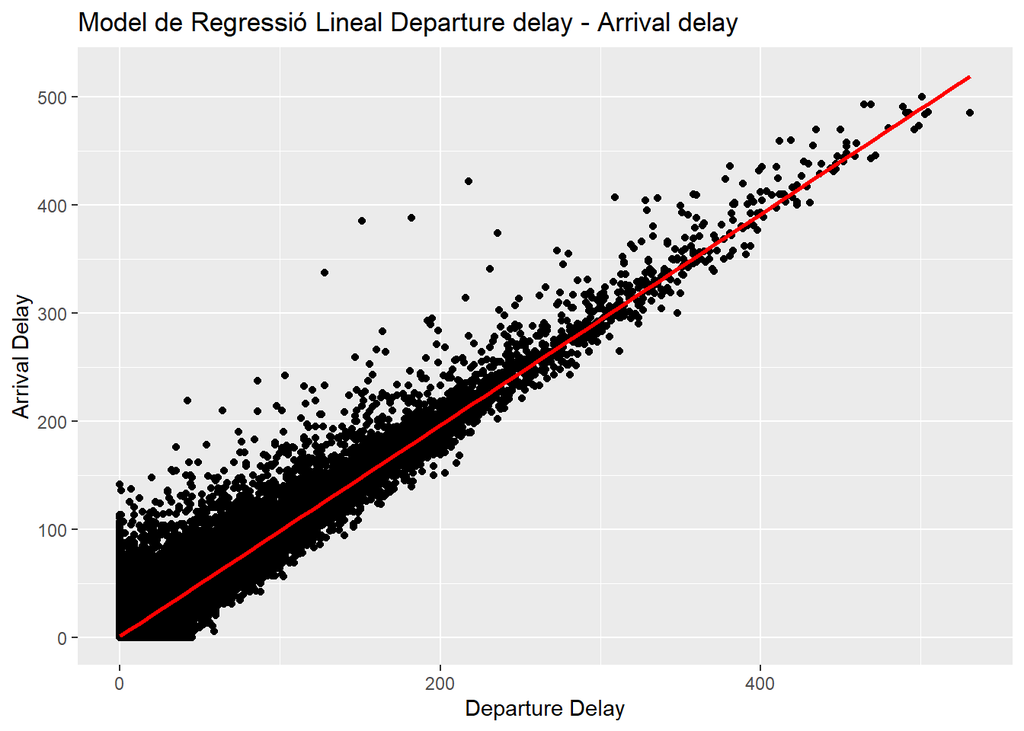

```r
#plot
plot.scatter.lm.departuredelayArrivaldelay
```

A part d’aquesta correlació, n’hem trobat diverses més, tot i que amb coeficients de correlació inferiors.

```r
#correlation OnlineBoarding-Wifi
cor(x = df$Wifi, y = df$Online_boarding, method = "pearson", use="pairwise.complete.obs")
```

```
## [1] 0.6318097
```

```r
#correlation BaggageHandling-Cleanliness
cor(x = df$Baggage_handling, y = df$Cleanliness, method = "pearson", use="pairwise.complete.obs")
```

```
## [1] 0.6322183
```

```r
#correlation OnlineBoarding-EaseBooking
cor(x = df$Online_boarding, y = df$Ease_booking, method = "pearson", use="pairwise.complete.obs")
```

```
## [1] 0.6844909
```

```r
#correlation SeatComfort-FoodDrink
cor(x = df$Seat_comfort, y = df$Food_drink, method = "pearson", use="pairwise.complete.obs")
```

```
## [1] 0.7160747
```

Per tal de comprovar correctament si existeix un cas de col·linealitat, utilitzarem de nou el factor d’inflació de la variància. Aquest factor calcula per a cada variable l’efecte combinat que tenen les dependències entre els diferents regressors sobre la variància de cada variable. Si ens trobem amb el cas on un o múltiples factors FIV prenen un valor gran, podem afirmar que tenim un cas de multicol·linealitat.

```r
#VIF
library(car)
vif(model.logisticRegression.gF)
```

```
##                       GVIF Df GVIF^(1/(2*Df))
## Gender            1.066347  1        1.032641
## Customer_Type     1.464883  1        1.210324
## Age               1.225340  1        1.106951
## Type_Travel       1.962163  1        1.400772
## Class             1.684013  2        1.139164
## Distance          1.197871  1        1.094473
## Seat_comfort      2.237164  1        1.495715
## Food_drink        2.527429  1        1.589789
## Gate              1.395862  1        1.181466
## Wifi              1.978653  1        1.406646
## Ent               1.414576  1        1.189360
## Ease_booking      2.910178  1        1.705924
## Service           1.598189  1        1.264195
## Baggage_handling  1.824836  1        1.350865
## Checkin_service   1.160322  1        1.077183
## Cleanliness       1.955570  1        1.398417
## Online_boarding   2.254557  1        1.501518
## Departure_Delay  12.778230  1        3.574665
## Arrival_Delay    12.794227  1        3.576902
```

Com podem observar als nostres resultats, tenim dos coeficients que són bastant grans. Aquest correponen al de les variables *Departure_Delay* i *Arrival_Delay*. És per aquest motiu que decidim eliminar una de les dues dins del nostre model. Així és com queda.

```r
#ModlgF
formula = numericSatisfaction~Gender+Customer_Type+Age+Type_Travel + Class + Distance + Seat_comfort + Food_drink + Gate + Wifi + Ent + Ease_booking + Service + Baggage_handling + Checkin_service + Cleanliness + Online_boarding + Arrival_Delay
model.logisticRegression.gF <- glm(formula=formula,family=binomial(link=logit), data=df.train)
summary(model.logisticRegression.gF)
```

```
##
## Call:
## glm(formula = formula, family = binomial(link = logit), data = df.train)
##
## Deviance Residuals:
##     Min       1Q   Median       3Q      Max
## -2.9468  -0.5900   0.2045   0.5426   3.5594
##
## Coefficients:
##                               Estimate Std. Error z value Pr(>|z|)
## (Intercept)                 -6.275e+00  7.029e-02 -89.278  < 2e-16 ***
## GenderMale                  -1.023e+00  1.820e-02 -56.182  < 2e-16 ***
## Customer_TypeLoyal Customer  1.900e+00  2.750e-02  69.093  < 2e-16 ***
## Age                         -6.935e-03  6.300e-04 -11.008  < 2e-16 ***
## Type_TravelPersonal Travel  -8.239e-01  2.581e-02 -31.927  < 2e-16 ***
## ClassEco                    -7.638e-01  2.361e-02 -32.356  < 2e-16 ***
## ClassEco Plus               -8.572e-01  3.608e-02 -23.760  < 2e-16 ***
## Distance                    -1.201e-04  9.479e-06 -12.670  < 2e-16 ***
## Seat_comfort                 2.714e-01  1.002e-02  27.090  < 2e-16 ***
## Food_drink                  -2.688e-01  9.951e-03 -27.016  < 2e-16 ***
## Gate                         2.997e-02  7.975e-03   3.758 0.000171 ***
## Wifi                        -8.819e-02  9.645e-03  -9.144  < 2e-16 ***
## Ent                          7.123e-01  8.836e-03  80.612  < 2e-16 ***
## Ease_booking                 3.386e-01  1.226e-02  27.615  < 2e-16 ***
## Service                      3.151e-01  9.126e-03  34.533  < 2e-16 ***
## Baggage_handling             1.272e-01  1.026e-02  12.397  < 2e-16 ***
## Checkin_service              2.936e-01  7.630e-03  38.475  < 2e-16 ***
## Cleanliness                  8.308e-02  1.066e-02   7.796 6.39e-15 ***
## Online_boarding              1.681e-01  1.052e-02  15.982  < 2e-16 ***
## Arrival_Delay               -5.383e-03  2.485e-04 -21.665  < 2e-16 ***
## ---
## Signif. codes:  0 '***' 0.001 '**' 0.01 '*' 0.05 '.' 0.1 ' ' 1
##
## (Dispersion parameter for binomial family taken to be 1)
##
##     Null deviance: 142640  on 103555  degrees of freedom
## Residual deviance:  81454  on 103536  degrees of freedom
## AIC: 81494
##
## Number of Fisher Scoring iterations: 5
```

### 2.2.3 Interpretació ModlgF

```r
#stepAIC ModelgF
model.gF.stepAIC <- stepAIC(model.logisticRegression.gF, trace = FALSE)
model.gF.stepAIC$anova
```

```
## Stepwise Model Path
## Analysis of Deviance Table
##
## Initial Model:
## numericSatisfaction ~ Gender + Customer_Type + Age + Type_Travel +
##     Class + Distance + Seat_comfort + Food_drink + Gate + Wifi +
##     Ent + Ease_booking + Service + Baggage_handling + Checkin_service +
##     Cleanliness + Online_boarding + Arrival_Delay
##
## Final Model:
## numericSatisfaction ~ Gender + Customer_Type + Age + Type_Travel +
##     Class + Distance + Seat_comfort + Food_drink + Gate + Wifi +
##     Ent + Ease_booking + Service + Baggage_handling + Checkin_service +
##     Cleanliness + Online_boarding + Arrival_Delay
##
##
##   Step Df Deviance Resid. Df Resid. Dev      AIC
## 1                     103536   81453.77 81493.77
```

Com podem observar al resultat obtingut, ens indica que el model inicial entrat pren el valor mínim AIC per la informació que intentem predir.

## 2.6 Predicció

En aquest apartat desitgem calcular la probabiltat de que el client número 3 del conjunt de dades de test estigui o no satisfet. Al resultat, obtenim que la probabilitat de que aquest client quedi satisfet és d’un 32.27%.

```r
library(pROC)
#Obtenim la row numero 3 del dataset de test
df.test[3,]
```

```
##       id            satisfaction Gender     Customer_Type Age     Type_Travel
## 15 68462 neutral or dissatisfied Female disloyal Customer  14 Business travel
##    Class Distance Seat_comfort Food_drink Gate Wifi Ent Ease_booking Service
## 15   Eco     2750            4          4    5    1   4            1       5
##    Baggage_handling Checkin_service Cleanliness Online_boarding Departure_Delay
## 15                4               3           4               1              32
##    Arrival_Delay numericSatisfaction
## 15             0                   0
```

```r
#Obtenim la predicció
glm.prediction <- predict (model.logisticRegression.gF, data.frame(Gender="Female",  Customer_Type="disloyal Customer", Age=14, Type_Travel="Business travel", Class="Eco", Distance=2750, Seat_comfort=4, Food_drink=4, Gate=5, Wifi=1, Ent=4, Ease_booking=1, Service=5, Baggage_handling=4, Checkin_service=3, Cleanliness=4, Online_boarding=1, Arrival_Delay=0), type="response")
#predicció
glm.prediction
```

```
##         1
## 0.3227508
```

## 2.7 Corba ROC

La corba ROC *(Receiver Operating Characteristics)* es tracta d’un gràfic que proporciona una manera de seleccionar possibles models òptims basat en la qualitat de la classsificació a diferents nivells.

```r
library(pROC)
prob=predict(model.logisticRegression.gF, df, type="response")
r=roc(df$numericSatisfaction,prob, data=df)
```

[output not shown]

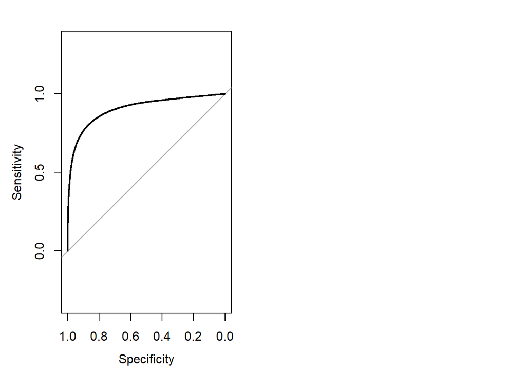

```r
par(mfrow=c(1,2))
plot(r)
auc(r)
```

# 3 Informe Executiu